# Машинное обучение. ВМК МГУ

## Практическое задание 2: Numpy + pandas + matplotlib

### Важно! О формате сдачи

- Все задания в этой части оцениваются по системе кросс-рецензирования.
- При решении ноутбука используйте данный шаблон. Не нужно удалять текстовые ячейки c разметкой частей ноутбука и формулировками заданий. Добавлять свои ячейки, при необходимости, конечно можно
- Везде, где в формулировке задания есть какой-либо вопрос (или просьба вывода), необходимо прописать ответ в ячейку (код или markdown).
- Наличие кода решения обязательно. Письменные ответы на вопросы без сопутствующего кода оцениваются в 0 баллов.
- Если в ячейке написана фраза "Вывод"/"Ответ на вопрос" итд, то ожидается ответ в виде текста (можете добавить ячейки с кодом, если считаете это необходимым, но это необязательно). Если в ячейке написано "Your code here" и пр. , то ожидается ответ в виде кода (можете добавить ячейки с кодом, если считаете это необходимым, но это необязательно). Если есть и ячейка с фразой "Вывод", и ячейка с фразой "Your code here", то в ответе ожидается и код, и текст
- Для удобства поиска вопросов, на которые от вас просят ответа, мы пометили их знаком (?)
- Многие из заданий можно выполнить несколькими способами. Не существуют единственно верного, но попробуйте максимально задействовать арсенал pandas и ориентируйтесь на простоту и понятность вашего кода. Не забывайте, что можно гуглить и что-то искать на stackoverflow, например.

## Подготовка рабочей среды

Сначала установим нужные нам версии библиотек. Мы гарантируем, что в данных версиях задание будет корректно отрабатывать.

После установки нужных версий, **возможно,** нужно перезагрузить среду (runtime), но скорее всего вам это не понадобится

На скачивание файла и установку понадобится не более 5 минут.

**Важно!** Устанавливать нужные версии нужно каждый раз, когда создается новый рантайм. Например, если вы 2 часа подряд делаете это задание, то подготовить библиотеки достаточно 1 раз. Но если вы, например, начали в понедельник, затем закрыли/выключили ноутбук, то при продолжении в среду, вам нужно будет запустить рантайм заново и следовательно заново установить библиотеки.

**Важно!** Если вы предпочитаете делать практические задания на своем личном ноутбуке, то проверьте, что вы установили рабочее окружение в [соответствии с гайдом](https://github.com/MSU-ML-COURSE/ML-COURSE-23-24/blob/main/tutorials/Туториал%20по%20установке%20рабочего%20окружения%20в%20Python%20для%20решения%20задач.pdf)

```python
# !!! Данный блок будет работать только в Google-Colab !!!
! gdown 1qa4VOOjn88tSEAXI_f-aKRzKldMdd5xS
! pip install -r /content/requirements.txt
```

[output not shown]

Проверим версию библиотеки:

```python
import catboost
assert(catboost.__version__ == '1.2.1')
```

Теперь можно приступать к выполнению задания! :)

# О задании

Задание состоит из трех частей, посвященных работе с табличными данными с помощью библиотеки **pandas**, визуализации с помощью библиотек **matplotlib**, **seaborn**, **plotly** и векторным вычислениям с помощью библиотеки **numpy**. Вам предлагается выполнить несколько заданий.

# Часть 1. Pandas

В этой части мы познакомимся с библиотекой **pandas**. **Pandas** — удобная библиотека для работы с табличными данными в Python, если данных не слишком много и они помещаются в оперативную память вашего компьютера.

С помощью встроенных инструментов **pandas** можно легко:

- считывать табличные данные (в форматах csv, json, xlsx)
- представлять собственные данные в виде таблиц и сохранять их
- считать статистики
- визулизировать данные
- производить обработку данных
- и много всего еще...

Основные объекты в **pandas**:

- **Series** (серия) — одномерная структура данных, в которой каждый элемент имеет свой индекс.
- **DataFrame** (датафрейм) - табличная структура данных, представляющая собой таблицу с именованными колонками различных типов и индексами строк.

Полезные материалы:

1. [Документация](http://pandas.pydata.org/pandas-docs/stable/index.html)
2. [Pandas за 10 минут из официального руководства](http://pandas.pydata.org/pandas-docs/stable/10min.html)
3. [Примеры использования функционала](http://nbviewer.jupyter.org/github/justmarkham/pandas-videos/blob/master/pandas.ipynb)

Далее потребуется выполнить несколько небольших заданий, покрывающих базовый функционал библиотеки.

```python
import pandas as pd
```

```python
!gdown 1sA-fqJb1WxhS_jaYDcIwXWa_b8b2oZJ6
```

```
Downloading...
From: https://drive.google.com/uc?id=1sA-fqJb1WxhS_jaYDcIwXWa_b8b2oZJ6
To: /content/youtube_trending_mediterranean.csv
100% 6.22M/6.22M [00:00<00:00, 27.6MB/s]
```

#### Задание 1 (0.8 балла).

- **(0.4 балла)** Откройте файл с таблицей, загруженной выше, и выведите последние 5 строк.
- **(0.4 балла)** **(?)** Посмотрите на данные и скажите, что они из себя представляют, сколько в таблице строк и столбцов?

Полезные материалы: https://pandas.pydata.org/pandas-docs/stable/getting_started/intro_tutorials/02_read_write.html

Возможно, пригодятся такие функции/методы:

- https://pandas.pydata.org/pandas-docs/stable/reference/api/pandas.read_csv.html
- https://pandas.pydata.org/pandas-docs/stable/reference/api/pandas.DataFrame.tail.html#pandas.DataFrame.tail
- https://pandas.pydata.org/pandas-docs/stable/reference/api/pandas.DataFrame.shape.html#pandas.DataFrame.shape

Преобразование данных из csv файла в dataframe pandas:

```python
df = pd.read_csv('/content/youtube_trending_mediterranean.csv')
```

Вывод последних 5 строк с попощью метода tail:

```python
df.tail(5)
```

|  | country | video_id | title | publishedAt | channelId | channelTitle | categoryId | trending_date | tags | view_count | comment_count | thumbnail_link | comments_disabled | ratings_disabled | description |
| --- | --- | --- | --- | --- | --- | --- | --- | --- | --- | --- | --- | --- | --- | --- | --- |
| 3216 | NaN | eB-A1Y0Dswc | Thank you for watching | 2022-07-05T21:18:33Z | UCS5tt2z_DFvG7-39J3aE-bQ | Life of Boris | 22 | 22.11.07 | lifeofboris\|life of boris\|english subtitles\|ye... | 864216 | 14431 | https://i.ytimg.com/vi/eB-A1Y0Dswc/default.jpg | False | True | New channel: https://www.youtube.com/channel/U... |
| 3217 | NaN | KJGTtzccOHU | Pokemon Emerald but every battle is extremely ... | 2022-07-05T01:55:10Z | UC0VVYtw21rg2cokUystu2Dw | SmallAnt | 20 | 22.11.07 | pokemon\|smallant\|smallant1\|challenge\|pokemon c... | 1311698 | 1232 | https://i.ytimg.com/vi/KJGTtzccOHU/default.jpg | False | True | Pokemon emerald but every battle is a 1v2You s... |
| 3218 | NaN | be8mqaTi_DI | Victor Cibrian x Fuerza Regida x Luis R Conriq... | 2022-07-04T21:00:36Z | UC648rgJOboZlgcDbW00vTSA | Rancho Humilde | 10 | 22.11.07 | Rancho Humilde\|Legado 7\|El De La Guitarra\|Fuer... | 2256933 | 597 | https://i.ytimg.com/vi/be8mqaTi_DI/default.jpg | False | True | SuscrÃbete: https://Rancho.lnk.to/RHYoutube\r... |
| 3219 | NaN | 14aYHc7ybu0 | WE STAYED AT A 1 STAR HOTEL FOR 24 HOURS \| coc... | 2022-07-05T13:40:04Z | UCSGoIq_tVESqNYF1Re-zn1Q | HJ Evelyn | 24 | 22.11.07 | hjevelyn\|Evelyn ha\|Emily ha\|erica ha\|korean si... | 922668 | 2951 | https://i.ytimg.com/vi/14aYHc7ybu0/default.jpg | False | True | never again ahaha.... CHECK OUT OUR MERCH: htt... |
| 3220 | NaN | mQ9eFI13NCQ | I 100%'d Cuphead: The Delicious Last Course, H... | 2022-07-04T16:04:33Z | UCRgzckrm1Svf-Y_dIWsTPTg | The Andrew Collette Show | 20 | 22.11.07 | cuphead\|cuphead dlc\|cuphead the delicious last... | 1176289 | 620 | https://i.ytimg.com/vi/mQ9eFI13NCQ/default.jpg | False | True | My Cuphead: The Delicious Last Course Let's Pl... |

Узнаем, сколько всего строк и столбцов, используя метод shape:

```python
print("Количество строк:\t", df.shape[0])
print("Количество столбцов:\t", df.shape[1])
```

```
Количество строк:	 3221
Количество столбцов:	 15
```

Посмотрим имена столбцов:

```python
print("Имена столбцов:")
for column in df.columns:
    print(column)
```

```
Имена столбцов:
country
video_id
title
publishedAt
channelId
channelTitle
categoryId
trending_date
tags
view_count
comment_count
thumbnail_link
comments_disabled
ratings_disabled
description
```

**Ответ**:

- данные представляют собой статистику видеороликов YouTube
- Количество строк: 3221 (нумерация с 0 до 3220)
- Количество столбцов: 15

#### Задание 2 (1.2 балла).

Ответьте на вопросы:

- **(0.4 балла)** **(?)** Для скольких стран (колонка country) есть информация о видеороликах в таблице (отсутствие страны НЕ учитывается как +1 значение)?
- **(0.4 балла)** **(?)** Сколько есть видеороликов (== записей в таблице) c разрешенными и запрещенными комментариями? (колонка comments_disabled). Под видеороликом считаем 1 запись в таблице.
- **(0.4 балла)** **(?)** Какое максимальное число просмотров у видеороликов, попавших в таблицу? (колонка view_count)

Базовый функционал, необxодимый для решения, можно найти [здесь](https://pandas.pydata.org/pandas-docs/stable/user_guide/basics.html).

Возможно, пригодятся следующие функции/методы:

- https://pandas.pydata.org/pandas-docs/stable/reference/api/pandas.Series.nunique.html#pandas.Series.nunique
- https://pandas.pydata.org/pandas-docs/stable/reference/api/pandas.Series.value_counts.html#pandas.Series.value_counts
- https://pandas.pydata.org/pandas-docs/stable/reference/api/pandas.Series.max.html#pandas.Series.max

```python
print("Количество стран с информацией о видеороликах:", df['country'].nunique(dropna=True))
print("Количество видеороликов с разрешенными комментариями:", df['comments_disabled'].value_counts()[False])
print("Количество видеороликов с запрещенными комментариями:", df['comments_disabled'].value_counts()[True])
print("Максимальное число просмотров у видеороликов:", df['view_count'].max())
```

```
Количество стран с информацией о видеороликах: 19
Количество видеороликов с разрешенными комментариями: 3193
Количество видеороликов с запрещенными комментариями: 28
Максимальное число просмотров у видеороликов: 123034293
```

**Ответ**:

1. Количество стран с информацией о видеороликах: 19
2. Количество видеороликов с разрешенными комментариями: 3193, a c запрещенными: 28
3. Максимальное число просмотров у видеороликов: 123034293

#### Задание 3 (1 балл)

**(0.4 балла)** **(?)** Есть ли в данных пропуски? В каких колонках?

Про работу с пропущенными значениями можно прочитать [здесь](https://pandas.pydata.org/pandas-docs/stable/user_guide/missing_data.html).

Возможно, пригодится такая функция: https://pandas.pydata.org/pandas-docs/stable/reference/api/pandas.DataFrame.isnull.html#pandas.DataFrame.isnull

```python
print("Колонки с пропущенными значениями:")
print(df.isnull().sum()[df.isnull().sum() > 0])
```

```
Колонки с пропущенными значениями:
country        200
description    131
dtype: int64
```

**Ответ**:

- Да, пропущенные значения есть только в 2 столбцах
- В столбце country: 200
- В столбце description: 131

**(0.6 балла)** Заполните пропуски пустой строкой для текстовых колонок, и удалите строки с пропусками для колонок с категориальными значениями.

Подсказка: Значения категориальной переменной определяют факт принадлежности к какой-то категории, категорий при этом должно быть ограниченное кол-во сильно меньшее размера датасета.

**Внимание!** Для проверки корректности выведите кол-во пропусков во всех столбцах и общее кол-во строк в таблице - должна быть 3021 запись. Ошибка при удалении строк может привести к неправильному выполнению следующих заданий.

**Что такое категориальная переменная?**

Категориальная переменная - колонка, которая имеет ограниченное число уникальных значений. Вообще говоря, может быть как типа object (текстовые), так и int (численные). В случае int можно считать, что категории закодированы числами. В таком случае значения нельзя сравнивать между собой и совершать над ними арифметические операции. В этом задании категориальные переменные только типа object.

Возможно, пригодятся такие функции:

- https://pandas.pydata.org/pandas-docs/stable/reference/api/pandas.DataFrame.fillna.html#pandas.DataFrame.fillna
- https://pandas.pydata.org/pandas-docs/stable/reference/api/pandas.DataFrame.dropna.html#pandas.DataFrame.dropna

```python
# Удаление строк с пропусками для колонок с категориальными значениями
df.dropna(subset=['country'], inplace=True)

# Заполнение пропусков пустой строкой для текстовых колонок
text_columns = df.select_dtypes(include='object').columns
df[text_columns] = df[text_columns].fillna('')

# Проверка количества пропусков и общего количества строк
print("Количество пропусков в каждом столбце:")
print(df.isnull().sum())
print("Общее количество строк в таблице:", len(df))
```

```
Количество пропусков в каждом столбце:
country              0
video_id             0
title                0
publishedAt          0
channelId            0
channelTitle         0
categoryId           0
trending_date        0
tags                 0
view_count           0
comment_count        0
thumbnail_link       0
comments_disabled    0
ratings_disabled     0
description          0
dtype: int64
Общее количество строк в таблице: 3021
```

#### Задание 4 (1.2 балла).

Посмотрите на колонку publishedAt

- **(0.2 балла) (?)** Какого она типа?
- **(0.4 балла)** Измените тип колонки на datetime. Покажите, что после изменения колонка действительно имеет тип datetime.
- **(0.6 балла) (?)** В какой месяц было добавлено больше всего видеороликов?

Полезные материалы: https://pandas.pydata.org/pandas-docs/stable/user_guide/timeseries.html

Возможно, пригодятся следующие функции/методы:

- https://pandas.pydata.org/pandas-docs/stable/reference/api/pandas.to_datetime.html#pandas-to-datetime
- https://pandas.pydata.org/pandas-docs/stable/reference/api/pandas.Series.dt.month.html#pandas.Series.dt.month

```python
print("Тип колонки publishedAt:\t", df['publishedAt'].dtype)

# Изменение типа колонки на datetime
df['publishedAt'] = pd.to_datetime(df['publishedAt'])

print("Новый тип колонки publishedAt:\t", df['publishedAt'].dtype)
print("Наибольшее количество видеороликов было добавлено в месяце номер:", df['publishedAt'].dt.month.value_counts().idxmax())
```

```
Тип колонки publishedAt:	 object
Новый тип колонки publishedAt:	 datetime64[ns, UTC]
Наибольшее количество видеороликов было добавлено в месяце номер: 7
```

**Ответ**:

1. Изначально колонка publishedAt была типа: object
2. Наибольшее количество видеороликов было добавлено в июле

#### Задание 5 (1.4 баллов).

Посмотрите на колонку description.

- **(0.4 балла)** Переведите строки в нижний регистр и обрежьте ненужные пробелы справа и слева.
- **(0.6 балла)** Замените url-адреса в описаниях на специальный тэг \<URL>.
- **(0.4 балла)** Выведите полностью description для видеоролика с video_id = 'Oxexirlmdig'.

Полезные материалы:

- Про работу с текстовыми данными в pandas: https://pandas.pydata.org/pandas-docs/stable/user_guide/text.html

Возможно, пригодятся следующие функции/методы:

- https://pandas.pydata.org/pandas-docs/stable/reference/api/pandas.Series.str.lower.html#pandas.Series.str.lower
- https://pandas.pydata.org/pandas-docs/stable/reference/api/pandas.Series.str.replace.html#pandas.Series.str.replace

```python
# Перевод строк в нижний регистр и обрезка пробелов
df['description'] = df['description'].str.lower().str.strip()

# Замена url-адресов на тэг <URL>
df['description'] = df['description'].str.replace(r'http\S+', '<URL>', regex=True)

print("Описание для видеоролика Oxexirlmdig:")
print(df.loc[df['video_id'] == 'Oxexirlmdig', 'description'].values[0])
```

```
Описание для видеоролика Oxexirlmdig:
music line & lyrics : ghetto geasy & majkmusic produced : bigdeal records mix & master: bigdeal recordsavailable on:spotify: <URL> <URL> <URL>
```

#### Задание 6 (0.8 балла).

**(0.8 балла)** **(?)** Какие 5 роликов набрали в Италии (country='IT') наибо8ьшее число просмотров (колонка view_count)? В качестве ответа привидите названия каналов с соответствующими роликами (колонка channelTitle) в порядке убывания числа просмотров.

Для решения воспользуйтесь функцией [sort_values](https://pandas.pydata.org/pandas-docs/stable/reference/api/pandas.DataFrame.sort_values.html).

```python
print(df[df['country'] == 'IT'].sort_values('view_count', ascending=False).head(5)['channelTitle'])
```

```
1630    That Little Puff
1599              SMTOWN
1570    Celine & Michiel
1631        SportsNation
1656         BeatboxJCOP
Name: channelTitle, dtype: object
```

**Ответ**:

1. That Little Puff
2. SMTOWN
3. Celine & Michiel
4. SportsNation
5. BeatboxJCOP

#### Задание 7 (0.8 балла).

**(0.8 балла)** **(?)** Какой видеоролик был опубликован в наибольшем кол-ве стран? В качестве ответа привeдите название видеоролика (колонка title).

Для решения могут помочь функции [groupby](https://pandas.pydata.org/pandas-docs/stable/reference/api/pandas.DataFrame.groupby.html) и [sort_values](https://pandas.pydata.org/pandas-docs/stable/reference/api/pandas.DataFrame.sort_values.html).

```python
print(df.groupby('title')['country'].nunique().reset_index().sort_values('country', ascending=False).iloc[0]['title'])
```

```
Race Highlights | 2022 British Grand Prix
```

**Ответ**: Race Highlights | 2022 British Grand Prix

#### Задание 8 (0.8 балла).

**(0.8 балла)** **(?)** Какое максимальное число просмотров (колонка view_count) у видеороликов, выпущенных во Франции или Италии (в колонке country значениe FR или IT) в июле (колонка publishedAt)?

Необходимо придумать решение в одну строку, используя для выбора строк несколько условий, объединенных с помощью | вместо or, & вместо and и ~ вместо not, а также используя функцию [isin](https://pandas.pydata.org/pandas-docs/stable/reference/api/pandas.DataFrame.isin.html).

```python
print(df[(df['country'].isin(['FR', 'IT'])) & (df['publishedAt'].dt.month == 7)]['view_count'].max())
```

```
82864422
```

**Ответ**: 82864422

#### Задание 9 (1 балл).

- **(0.2 балла)** **(?)** Посмотрите на названия каналов из 17 категории (колонка categoryId). Как вы думаете, что это за категория?
- **(0.8 балла)** Предположим, что была допущена ошибка, и все видеоролики из 17 категории, относятся к 16 категории. Исправьте нужные значения в колонке categoryId, после чего выведите все уникальные категории.

Обратите внимание, что при выборе полей с помощью оператора индексирования [] возвращается копия выбранных значений. При попытке присвоить таким образом новые значения для некоторых полей таблицы, будет выдано предупреждение. Более надежный способ - использовать операторы loc и iloc. Подробнее про индексацию и выбор строк можно прочитать [здесь](https://pandas.pydata.org/pandas-docs/stable/user_guide/indexing.html).

Возможно, пригодится следующая функция:

- https://pandas.pydata.org/pandas-docs/stable/reference/api/pandas.Series.unique.html#pandas.Series.unique

```python
print("Названия каналов из 17 категории:")
print(df[df['categoryId'] == 17]['channelTitle'])
```

```
Названия каналов из 17 категории:
46        Omar Raja - ESPN
72               FORMULA 1
75            Dude Perfect
116             TyC Sports
140           SportsNation
               ...
2970          Karakullukcu
2984    SansÃ¼rsÃ¼z Futbol
2989             FORMULA 1
2998         BeÅiktaÅ JK
3016               S Sport
Name: channelTitle, Length: 213, dtype: object
```

```python
df.loc[df['categoryId'] == 17, 'categoryId'] = 16
print("Все уникальные категории:")
print(*df['categoryId'].unique())
```

```
Все уникальные категории:
24 10 1 15 22 23 27 16 20 26 25 2 19 28
```

**Ответ**: 17 категрия - спорт, спортивные игры и развлечения

#### Задание 10 (2 балла).

Посмотрите на колонку tags.

- **(0.4 балла)** Замените строки со значением '[none]' на пустую строку.
- **(1.6 балла)** **(?)** Какой самый популярный тэг? Обратите внимание, что у каждого видеоролика может быть более 1 тэга.

Для предобработки данных могут помочь функции [apply](https://pandas.pydata.org/pandas-docs/stable/reference/api/pandas.DataFrame.apply.html) и [explode](https://pandas.pydata.org/pandas-docs/stable/reference/api/pandas.DataFrame.explode.html).

**Подсказка 1**

Чтобы получить правильное значение, не забудьте обработать множество тэгов - убрать пробельные символы по краям и привести строки в нижний регистр.

**Подсказка 2**

Нужный тэг встречается больше 130 раз.

```python
# Замените строки со значением '[none]' на пустую строку.
df['tags'] = df['tags'].apply(lambda x: '' if x == '[none]' else x)

x = df['tags'].str.split('|').explode().str.strip().str.lower()
print("Самый популярный тэг:", x.drop(x[x == ''].index).mode()[0])
print("Встречается", x.drop(x[x == ''].index).value_counts()[0], "раз")
```

```
Самый популярный тэг: challenge
Встречается 133 раз
```

**Ответ**:

- Самый популярный тэг: challenge
- Встречается 133 раз

# Часть 2. Визуализация данных

### Оформление графиков

Важно, чтобы все графики выглядели опрятно и соответствовали следующим правилам:

- должно быть название (plt.title) графика;
- на графиках должны быть подписаны оси (plt.xlabel, plt.ylabel);
- должны быть подписаны единицы измерения (если это возможно);
- все названия должны быть понятны любому человеку, знакомому с терминологией, без заглядывания в код;
- подписи тиков на осях не должны сливаться как на одной оси, так и между ними;
- если изображено несколько сущностей на одном холсте (например несколько функций), то необходима поясняющая легенда (plt.legend);
- все линии на графиках должны быть чётко видны (нет похожих цветов или цветов, сливающихся с фоном);
- если отображена величина, имеющая очевидный диапазон значений (например, проценты могут быть от 0 до 100), то желательно масштабировать ось на весь диапазон значений (исключением является случай, когда вам необходимо показать малое отличие, которое незаметно в таких масштабах);
- графики должны быть не супер-микро и не супер-макро по размерам, так, чтобы можно было увидеть все, что нужно.
- при необходимости улучшения наглядности графиков, можно пользоваться логарифмической шкалой по осям x/y.

```python
import matplotlib
import matplotlib.pyplot as plt

#отображение графиков в ноутбуке
%matplotlib inline

#для четкой прорисовки графиков - осторожно!!! Может съедать много памяти
#закоменьте эту строку, если это случилось
%config InlineBackend.figure_format = 'svg'
```

Далее вам нужно построить несколько визуализаций табличных данных о видео, с которыми мы работали в 1 части задания.

### Важно!

- Проверьте, что при конвертации в html формат все графики остаются видны. Это нужно для дальнейшей проверки в проверяющей системе. Проверить это можно непосредственно загрузив задание в систему и посмотреть на свою отправленную посылку (как это сделать - можно почитать в [туториале](https://github.com/MSU-ML-COURSE/ML-COURSE-22-23/blob/main/files/Работа%20в%20проверяющей%20системе.pdf))
- При решении заданий вы можете воспользоваться любыми средствами для визуализации.
- Все графики должны выглядеть опрятно и соответствовать правилам, перечисленным в начале Части 2. В случае несоответствия хотя бы 3 пунктам оценка снижается на 0.5 балла.

### Задание 1 (3 балла).

Постройте график (line plot) зависимости кол-ва выпущенных роликов от даты публикации.

Обратите внимание, что один и тот же ролик может быть опубликован в нескольких странах, и ему может соответствовать несколько строк в таблице. На графике необходимо учесть каждый ролик только 1 раз.

```python
# Группировка данных по дате публикации и подсчет количества роликов
grouped_data = df.groupby('publishedAt').nunique().video_id

# Построение графика
plt.title('Зависимость количества выпущенных роликов от даты публикации')
plt.xlabel('Дата публикации')
plt.ylabel('Количество роликов')
plt.plot(grouped_data.index, grouped_data.values)
plt.xticks(rotation=90)
plt.show()
```

[figure not shown]

### Задание 2 (3 балла).

Постройте диаграмму (bar plot) кол-ва опубликованных роликов в зависимости от страны.

```python
grouped_data = df.groupby('country').size()

plt.title('Количество опубликованных роликов в зависимости от страны')
plt.xlabel('Страна')
plt.ylabel('Количество роликов')
plt.bar(grouped_data.index, grouped_data.values)
plt.xticks(rotation=0)
plt.show()
```

[figure not shown]

### Задание 3 (3 балла).

Постройте график (scatter plot) зависимости кол-ва комментариев для ролика от кол-ва просмотров для роликов во Франции (country='FR'). На графике не нужно учитывать ролики с отключенными комментариями (comments_disabled=True). Какой характер зависмости получился?

```python
filtered_data = df[(df['country'] == 'FR') & (df['comments_disabled'] == False)]

plt.title('Зависимость количества комментариев от количества просмотров (Франция)')
plt.xlabel('Количество просмотров')
plt.ylabel('Количество комментариев')
plt.scatter(filtered_data['view_count'], filtered_data['comment_count'])
plt.show()
```

[figure not shown]

**Ответ**: в зависимости от рассматриваемого диапазона характер зависимости близок к степенной или линейной функции

# Часть 3. Numpy

```python
import numpy as np
```

### Важно!

- **Файлы functions.py и functions_vectorised.py с реализованными функциями необходимо сдать на тестирование в проверяющей системе.**

### Задачи 1-6 (13 баллов).

Для каждой из задач ниже привидите 2 реализации: одна без использования numpy, а вторая полностью векторизованная (**без использования циклов/map/list comprehension**). Реализации без использования векторизации нужно записать в файл functions.py, а векторизованные — в файл functions_vectorised.py (см. шаблоны).

**Внимание!**

Векторизованные реализации с использованием циклов/map/list comprehension оцениваются в 0 баллов.

Невекторизованная реализация каждой из задач оценивается в **1.5 балла**, векторизованная – в **3 балла**.

- **Задача 1**: Посчитать сумму неотрицательных элементов на диагонали прямоугольной матрицы X. Если неотрицательных элементов на диагонали нет, то вернуть -1.

  **Пример:**

  ```
  Input: X = np.array([[-1, 0, 1], [2, 0, 2], [3, 0, 3], [4, 4, 4]])
  Output: 3
  ```

- **Задача 2**: Даны два вектора x и y. Проверить, задают ли они одно и то же мультимножество.

  **Пример:**

  ```
  Input: x = [1, 2, 2, 4], y = [4, 2, 1, 2]
  Output: True
  ```

- **Задача 3**: Найти максимальное прозведение соседних элементов в массиве x, таких что хотя бы один множитель в произведении делится на 3. Если таких произведений нет, то вернуть -1.

  **Пример**

  ```
  Input: x = [6, 2, 0, 3, 0, 0, 5, 7, 0]
  Output: 12
  ```

- **Задача 4**: Дан трёхмерный массив image, содержащий изображение, размера (height, width, num_channels), а также вектор весов weights длины num_channels. Сложить каналы изображения с указанными весами, и вернуть результат в виде матрицы размера (height, width). *Обратите внимание, что в изображении может быть не три канала!*

  **Пример:**

  ```
  Input: image = [[[1, 1, 1], [2, 2, 2], [3, 3, 3]], [[4, 4, 4], [5, 5, 5], [6, 6, 6]], [[7, 7, 7], [8, 8, 8], [9, 9, 9]]], weights= [1, 2, 3]
  Output: [[6, 12, 18], [24, 30, 36], [42, 48, 54]]
  ```

  **Комментарий**:
  - В примере исходное изображение с тремя каналами, где по всем каналам значения равны [[1, 2, 3], [4, 5, 6], [7, 8, 9]].
  - После умножения первого канала на вес 1 получим значения для первого канала [[1, 2, 3], [4, 5, 6], [7, 8, 9]].
  - После умножения второго канала на вес 2 получим значения для второго канала [[2, 4, 6], [8, 10, 12], [14, 16, 18]].
  - После умножения третьего канала на вес 3 получим значения для третьего канала [[3, 6, 9], [12, 15, 18], [21, 24, 27]].
  - Если сложить полученное изображение поканально получим [[6, 12, 18], [24, 30, 36], [42, 48, 54]].
- **Задача 5**: Найти скалярное произведение между векторами x и y, заданными в формате RLE (Run-length encoding, кодирование длин серий). Каждый закодированный вектор представлен двумерным массивом, каждая строка которого имеет размерность 2, где первое число - элемент, а второе число - сколько раз элемент нужно повторить. Например, [[1,2], [2, 3], [3, 1]] соответствует веткору [1, 1, 2, 2, 2, 3]. В случае несовпадения длин исходных векторов вернуть -1.

  **Пример:**

  ```
  Input: x = [[1, 2], [2, 3], [3, 1]], y = [[1, 1], [0, 5]].
  Output: 1
  ```

- **Задача 6**: Даны две выборки объектов - X и Y. Вычислить матрицу косинусных расстояний между объектами X и Y. Пусть X - матрица n объектов размера (n, d), Y - матрица из m объектов размера (m, d), тогда матрица косинусных расстояний M - матрица размера (n, m), где m_ij - косинус угла между i-м объектом из матрицы Х (i-ая строка) и j-м объектом из матрицы Y (j-ая строка матрицы Y). Если хотя бы один из векторов равен 0, то косинусное расстояние определим равным 1.

  **Пример:**

  ```
  Input: X = [[0, 0, 0], [1, 0, 0]], Y = [[1, 0, 0], [0, 1, 0], [0, 0, 1]]
  Output: [[1, 1, 1], [1, 0, 0]]
  ```

**Замечание.** Можно считать, что все входные данные непустые и коректные.

### Важно!

- **Следующее задание оценивается по системе кросс-рецензирования.**

### Задача 7 (7 баллов).

- **(6 баллов)** Для каждой задачи сравните скорость работы невекторизованной и векторизованной реализации. Для этого постройте графики времени работы векторизованной и невекторизованной реализации в зависимости от размера данных. Код генерации данных разных размеров и функция для замера времени работы функций уже написаны.
- **(1 балл) (?)** Сделайте выводы о времени работы функций.

**Важно!** В текущую директорию необходимо загрузить файлы functions.py и functions_vectorised.py с реализованными функциями. В Google Colab это можно сделать, нажав на значок "папки" слева, дальше на "загрузить" (значок листа со стрелкой вверх). Загружать нужно в папку "sample_data" (она у вас откроется по умолчанию)

```python
import time
import numpy as np

import functions_vectorised
import functions
```

```python
# генерация данных

sum_non_neg_diag_data = []
for n in [10, 100, 1000, 10000]:
    X = np.random.randint(0, 3, (n, n))
    sum_non_neg_diag_data += [X]

are_multisets_equal_data = []
for n in [10, 100, 1000, 10000]:
    x = np.random.randint(0, 2, n)
    y = np.random.randint(0, 2, n)
    are_multisets_equal_data += [(x, y)]

max_prod_mod_3_data = []
for n in [10, 100, 1000, 10000]:
    x = np.random.randint(1, 100, n)
    max_prod_mod_3_data += [x]

convert_image_data = []
for n in [10, 100, 1000]:
    image = np.random.random((n, n, 10))
    weights = np.random.random(10)
    convert_image_data += [(image, weights)]

rle_scalar_data = []
for n in [10, 100, 1000, 10000]:
    x = np.random.randint(1, 3, (n, 2))
    y = np.random.randint(1, 3, (n, 2))
    shapes = np.random.randint(1, 3, n)
    x[:, 1] = shapes
    y[:, 1] = shapes

    rle_scalar_data += [(x, y)]

cosine_distance_data = []
for n in [10, 100]:
    X = np.random.random((n, n))
    Y = np.random.random((n, n))
    cosine_distance_data += [(X, Y)]
```

```python
# функция для подсчета времени работы

def count_time(func, *data):
    tick = time.perf_counter()
    func(*data)
    return time.perf_counter() - tick
```

```python
# sum_non_neg_diag
sum_non_neg_diag_time = []
sum_non_neg_diag_vectorised_time = []
for X in sum_non_neg_diag_data:
    sum_non_neg_diag_time.append(count_time(functions.sum_non_neg_diag, X))
    sum_non_neg_diag_vectorised_time.append(count_time(functions_vectorised.sum_non_neg_diag, X))

# are_multisets_equa
are_multisets_equal_time = []
are_multisets_equal_vectorised_time = []
for x, y in are_multisets_equal_data:
    are_multisets_equal_time.append(count_time(functions.are_multisets_equal, x, y))
    are_multisets_equal_vectorised_time.append(count_time(functions_vectorised.are_multisets_equal, x, y))

# max_prod_mod_3
max_prod_mod_3_time = []
max_prod_mod_3_vectorised_time = []
for x in max_prod_mod_3_data:
    max_prod_mod_3_time.append(count_time(functions.max_prod_mod_3, x))
    max_prod_mod_3_vectorised_time.append(count_time(functions_vectorised.max_prod_mod_3, x))

# convert_image
convert_image_time = []
convert_image_vectorised_time = []
for image, weights in convert_image_data:
    convert_image_time.append(count_time(functions.convert_image, image, weights))
    convert_image_vectorised_time.append(count_time(functions_vectorised.convert_image, image, weights))

# rle_scalar
rle_scalar_time = []
rle_scalar_vectorised_time = []
for x, y in rle_scalar_data:
    rle_scalar_time.append(count_time(functions.rle_scalar, x, y))
    rle_scalar_vectorised_time.append(count_time(functions_vectorised.rle_scalar, x, y))

# cosine_distance
cosine_distance_time = []
cosine_distance_vectorised_time = []
for X, Y in cosine_distance_data:
    cosine_distance_time.append(count_time(functions.cosine_distance, X, Y))
    cosine_distance_vectorised_time.append(count_time(functions_vectorised.cosine_distance, X, Y))
```

```python
import matplotlib.pyplot as plt

# Размеры данных
sizes = [10, 100, 1000, 10000]

# График для невекторизованной реализации
plt.plot(sizes, sum_non_neg_diag_time, label='Non-vectorized')
# График для векторизованной реализации
plt.plot(sizes, sum_non_neg_diag_vectorised_time, label='Vectorized')

plt.xlabel('Data Size')
plt.ylabel('Execution Time (s)')
plt.title('sum_non_neg_diag')
plt.legend()
plt.show()
```

[figure not shown]

```python
# Размеры данных
sizes = [10, 100, 1000, 10000]

# График для невекторизованной реализации
plt.plot(sizes, are_multisets_equal_time, label='Non-vectorized')
# График для векторизованной реализации
plt.plot(sizes, are_multisets_equal_vectorised_time, label='Vectorized')

plt.xlabel('Data Size')
plt.ylabel('Execution Time (s)')
plt.title('are_multisets_equal')
plt.legend()
plt.show()
```

[figure not shown]

```python
# Размеры данных
sizes = [10, 100, 1000, 10000]

# График для невекторизованной реализации
plt.plot(sizes, max_prod_mod_3_time, label='Non-vectorized')
# График для векторизованной реализации
plt.plot(sizes, max_prod_mod_3_vectorised_time, label='Vectorized')

plt.xlabel('Data Size')
plt.ylabel('Execution Time (s)')
plt.title('max_prod_mod_3')
plt.legend()
plt.show()
```

[figure not shown]

```python
# Размеры данных
sizes = [10, 100, 1000]

# График для невекторизованной реализации
plt.plot(sizes, convert_image_time, label='Non-vectorized')
# График для векторизованной реализации
plt.plot(sizes, convert_image_vectorised_time, label='Vectorized')

plt.xlabel('Data Size')
plt.ylabel('Execution Time (s)')
plt.title('convert_image')
plt.legend()
plt.show()
```

[figure not shown]

```python
# Размеры данных
sizes = [10, 100, 1000, 10000]

# График для невекторизованной реализации
plt.plot(sizes, rle_scalar_time, label='Non-vectorized')
# График для векторизованной реализации
plt.plot(sizes, rle_scalar_vectorised_time, label='Vectorized')

plt.xlabel('Data Size')
plt.ylabel('Execution Time (s)')
plt.title('rle_scalar')
plt.legend()
plt.show()
```

[figure not shown]

```python
# Размеры данных
sizes = [10, 100]

# График для невекторизованной реализации
plt.plot(sizes, cosine_distance_time, label='Non-vectorized')
# График для векторизованной реализации
plt.plot(sizes, cosine_distance_vectorised_time, label='Vectorized')

plt.xlabel('Data Size')
plt.ylabel('Execution Time (s)')
plt.title('cosine_distance')
plt.legend()
plt.show()
```

[figure not shown]

[figure not shown]

## Бонусное задание (2 балла)

Вставьте/придумайте мем про pandas/машинное обучение/Python или просто милую картинку с пандой

[figure not shown]

Важно: самый простой способ вставить картинку будет через Google Colab (даже если вы изначально делали не в нем). Нажмите на **"+ Text"**, в появившейся ячейке сделайте **прикрепление картинки** (как на скринах). Тогда ваша картинка "зашифруется" и будет корректно отображаться при конвертации в html

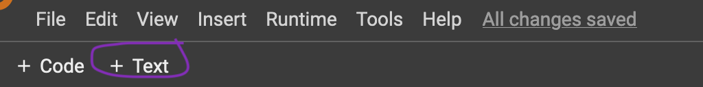

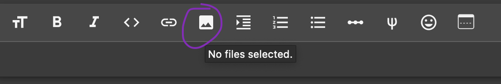